# employee_retention

## Business Problem

Organisation are recognizing that its employees are its most valuable asset, and their skills, knowledge, and dedication play a pivotal role in driving the company’s success. However, a growing number of employees have been leaving the organization for various reasons, including better opportunities elsewhere, lack of career growth prospects, dissatisfaction with management, and a perceived decline in work-life balance.

The consequences of employee turnover are multifaceted and far-reaching, affecting the company’s bottom line and its ability to remain competitive. High employee turnover not only incurs substantial recruitment and onboarding costs but also disrupts team dynamics, leading to a loss of institutional knowledge and expertise. Furthermore, the constant need to replace departing employees hinders the continuity of projects, delays product development timelines, and may result in compromised product quality.

Moreover, the increasing rate of attrition has sparked concerns about the overall workplace environment and the company’s ability to retain top talent, particularly as competitors actively seek to recruit skilled professionals.

The goal of this employee retention project is to identify the root causes of employee turnover, determine the factors influencing employee engagement, and develop comprehensive strategies and initiatives to improve retention rates. The research will encompass a thorough analysis of the company’s culture, leadership practices, career development opportunities, compensation and benefits packages, work-life balance policies, and overall employee satisfaction.

## Data Understanding

In this employee retention project, our dataset encompasses details pertaining to individuals who have been part of an organization’s workforce. The dataset is accessible through the following link: [HR Analytics Employee Retention Dataset](https://www.kaggle.com/datasets/rishikeshkonapure/hr-analytics-prediction). It’s important to note that the dataset exhibits a significant class imbalance; specifically, only 16% of the instances within the dataset represent employees who have voluntarily departed from the organization, while the majority of instances pertain to employees who have not left. This imbalance could potentially impact the performance and reliability of any predictive models or analyses we undertake as part of this project.

Summary of Numeric Variables

| Vname | Group | TN | nZero | nPos | min | max | mean | median | SD | CV | IQR | Skewness | Kurtosis |
| --- | --- | --- | --- | --- | --- | --- | --- | --- | --- | --- | --- | --- | --- |
| Age | All | 1470 | 0 | 1470 | 18 | 60 | 36.924 | 36.0 | 9.135 | 0.247 | 13.00 | 0.413 | -0.407 |
| DailyRate | All | 1470 | 0 | 1470 | 102 | 1499 | 802.486 | 802.0 | 403.509 | 0.503 | 692.00 | -0.004 | -1.204 |
| DistanceFromHome | All | 1470 | 0 | 1470 | 1 | 29 | 9.193 | 7.0 | 8.107 | 0.882 | 12.00 | 0.957 | -0.228 |
| EmployeeNumber | All | 1470 | 0 | 1470 | 1 | 2068 | 1024.865 | 1020.5 | 602.024 | 0.587 | 1064.50 | 0.017 | -1.223 |
| HourlyRate | All | 1470 | 0 | 1470 | 30 | 100 | 65.891 | 66.0 | 20.329 | 0.309 | 35.75 | -0.032 | -1.196 |
| MonthlyIncome | All | 1470 | 0 | 1470 | 1009 | 19999 | 6502.931 | 4919.0 | 4707.957 | 0.724 | 5468.00 | 1.368 | 0.998 |
| MonthlyRate | All | 1470 | 0 | 1470 | 2094 | 26999 | 14313.103 | 14235.5 | 7117.786 | 0.497 | 12414.50 | 0.019 | -1.215 |
| NumCompaniesWorked | All | 1470 | 197 | 1273 | 0 | 9 | 2.693 | 2.0 | 2.498 | 0.928 | 3.00 | 1.025 | 0.006 |
| PercentSalaryHike | All | 1470 | 0 | 1470 | 11 | 25 | 15.210 | 14.0 | 3.660 | 0.241 | 6.00 | 0.820 | -0.304 |
| TotalWorkingYears | All | 1470 | 11 | 1459 | 0 | 40 | 11.280 | 10.0 | 7.781 | 0.690 | 9.00 | 1.116 | 0.911 |
| YearsAtCompany | All | 1470 | 44 | 1426 | 0 | 40 | 7.008 | 5.0 | 6.127 | 0.874 | 6.00 | 1.763 | 3.918 |
| YearsInCurrentRole | All | 1470 | 244 | 1226 | 0 | 18 | 4.229 | 3.0 | 3.623 | 0.857 | 5.00 | 0.916 | 0.472 |
| YearsSinceLastPromotion | All | 1470 | 581 | 889 | 0 | 15 | 2.188 | 1.0 | 3.222 | 1.473 | 3.00 | 1.982 | 3.596 |
| YearsWithCurrManager | All | 1470 | 263 | 1207 | 0 | 17 | 4.123 | 3.0 | 3.568 | 0.865 | 5.00 | 0.833 | 0.166 |

Summary of Categorical Variables

| Variable | Target | Unique | Chi-squared | p-value | df | IV Value | Cramers V | Degree of Association |
| --- | --- | --- | --- | --- | --- | --- | --- | --- |
| Department | Attrition | 3 | 10.796 | 0.006 | NA | 0 | 0.09 | Weak |
| EducationField | Attrition | 6 | 16.025 | 0.010 | NA | 0 | 0.10 | Weak |
| Gender | Attrition | 2 | 1.275 | 0.276 | NA | 0 | 0.03 | Very Weak |
| JobRole | Attrition | 9 | 86.190 | 0.000 | NA | 0 | 0.24 | Moderate |
| MaritalStatus | Attrition | 3 | 46.164 | 0.000 | NA | 0 | 0.18 | Weak |
| OverTime | Attrition | 2 | 89.044 | 0.000 | NA | 0 | 0.25 | Moderate |
| BusinessTravel | Attrition | 3 | 24.182 | 0.001 | NA | 0 | 0.13 | Weak |
| Education | Attrition | 5 | 3.074 | 0.552 | NA | 0 | 0.05 | Very Weak |
| EnvironmentSatisfaction | Attrition | 4 | 22.504 | 0.000 | NA | 0 | 0.12 | Weak |
| JobInvolvement | Attrition | 4 | 28.492 | 0.000 | NA | 0 | 0.14 | Weak |
| JobLevel | Attrition | 5 | 72.529 | 0.000 | NA | 0 | 0.22 | Moderate |
| JobSatisfaction | Attrition | 4 | 17.505 | 0.001 | NA | 0 | 0.11 | Weak |
| RelationshipSatisfaction | Attrition | 4 | 5.241 | 0.155 | NA | 0 | 0.06 | Very Weak |
| StockOptionLevel | Attrition | 4 | 60.598 | 0.000 | NA | 0 | 0.20 | Moderate |
| WorkLifeBalance | Attrition | 4 | 16.325 | 0.001 | NA | 0 | 0.11 | Weak |
| NumCompaniesWorked | Attrition | 10 | 25.744 | 0.002 | NA | 0 | 0.13 | Weak |
| PerformanceRating | Attrition | 2 | 0.012 | 0.905 | NA | 0 | 0.00 | Very Weak |
| TrainingTimesLastYear | Attrition | 7 | 15.146 | 0.028 | NA | 0 | 0.10 | Weak |
| Age | Attrition | 10 | 67.207 | 0.000 | NA | 0 | 0.21 | Moderate |
| DailyRate | Attrition | 10 | 15.758 | 0.068 | NA | 0 | 0.10 | Weak |
| DistanceFromHome | Attrition | 9 | 16.064 | 0.037 | NA | 0 | 0.10 | Weak |
| EmployeeNumber | Attrition | 10 | 5.840 | 0.773 | NA | 0 | 0.06 | Very Weak |
| HourlyRate | Attrition | 10 | 10.141 | 0.333 | NA | 0 | 0.08 | Very Weak |
| MonthlyIncome | Attrition | 10 | 78.681 | 0.000 | NA | 0 | 0.23 | Moderate |
| MonthlyRate | Attrition | 10 | 10.670 | 0.303 | NA | 0 | 0.09 | Weak |
| PercentSalaryHike | Attrition | 8 | 8.347 | 0.299 | NA | 0 | 0.08 | Very Weak |
| TotalWorkingYears | Attrition | 9 | 81.044 | 0.000 | NA | 0 | 0.23 | Moderate |
| YearsAtCompany | Attrition | 9 | 78.521 | 0.000 | NA | 0 | 0.23 | Moderate |
| YearsInCurrentRole | Attrition | 7 | 53.105 | 0.000 | NA | 0 | 0.19 | Moderate |
| YearsSinceLastPromotion | Attrition | 5 | 2.998 | 0.555 | NA | 0 | 0.05 | Very Weak |
| YearsWithCurrManager | Attrition | 7 | 54.632 | 0.000 | NA | 0 | 0.19 | Moderate |

## Exploratory Data Analysis

The exploratory analysis would be carried out based on employee profile

**Demographic**

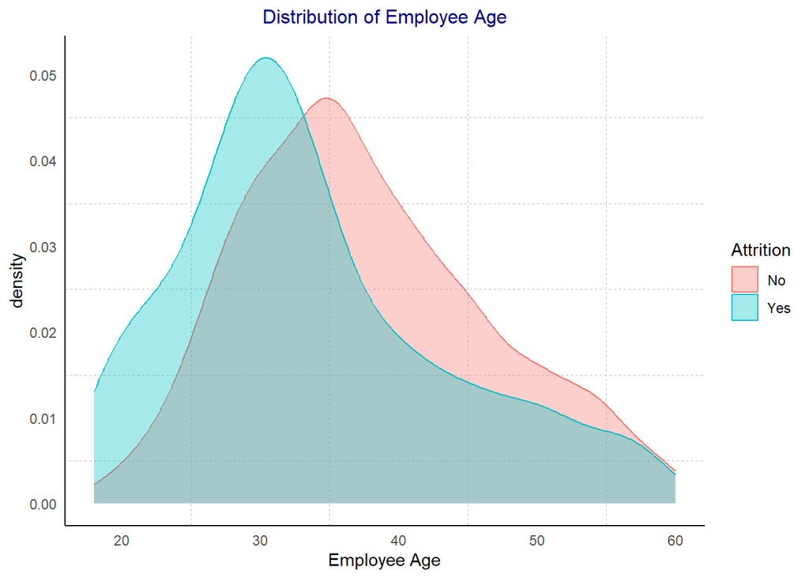

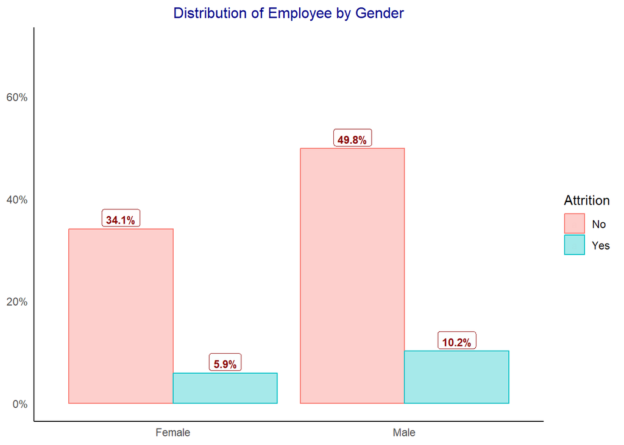

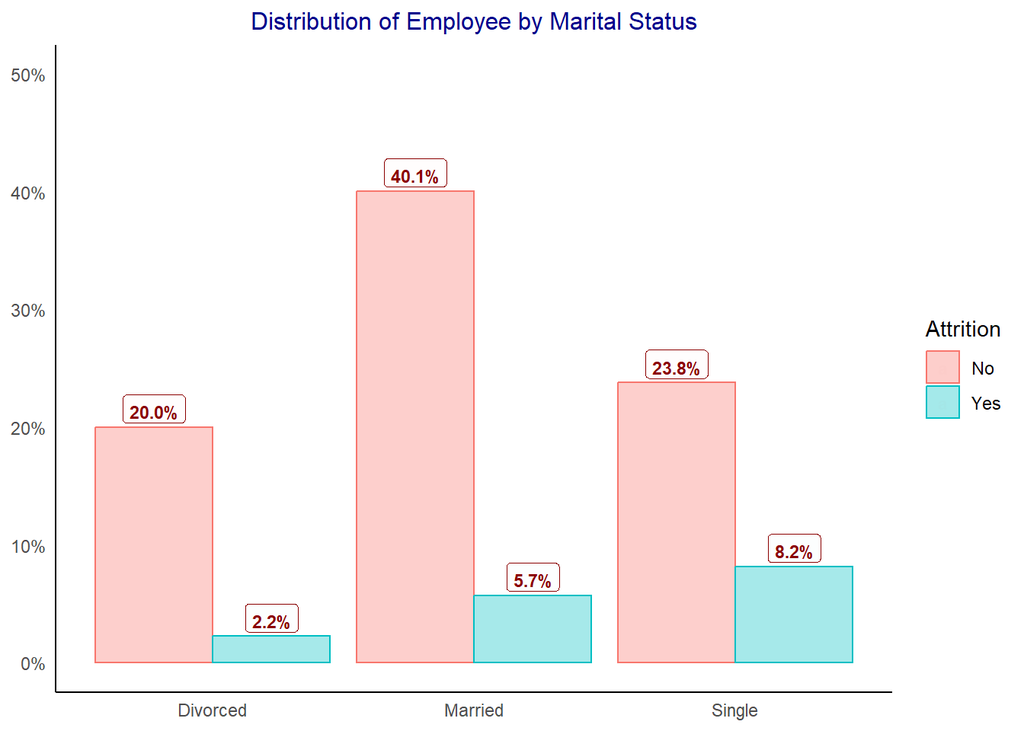

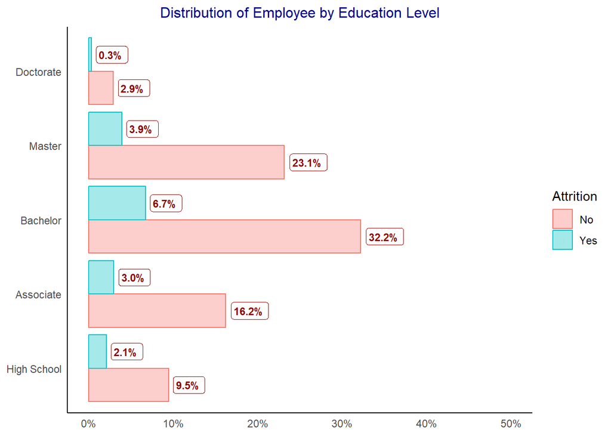

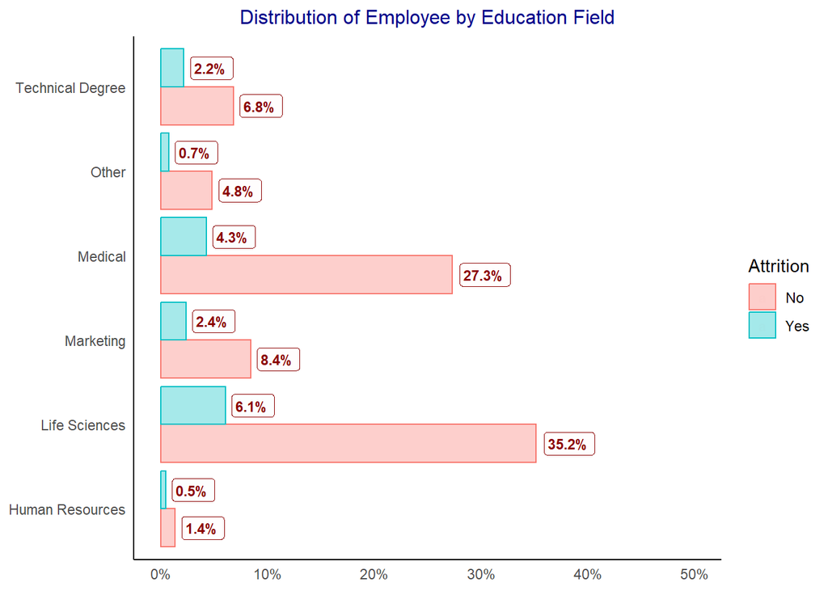

**Compensation**

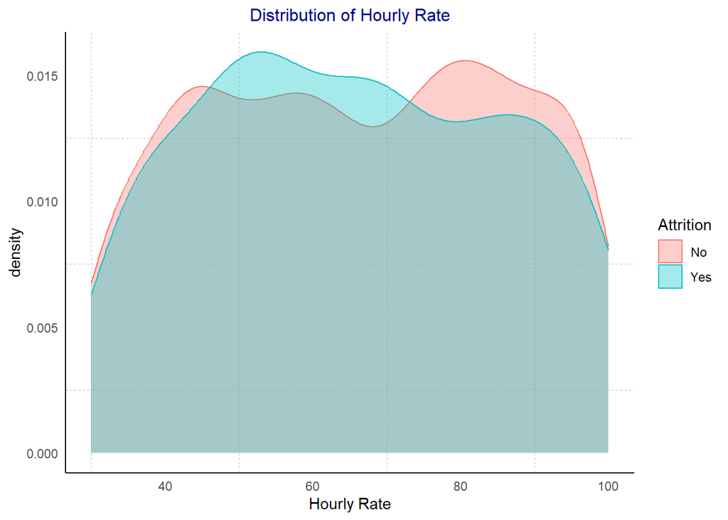

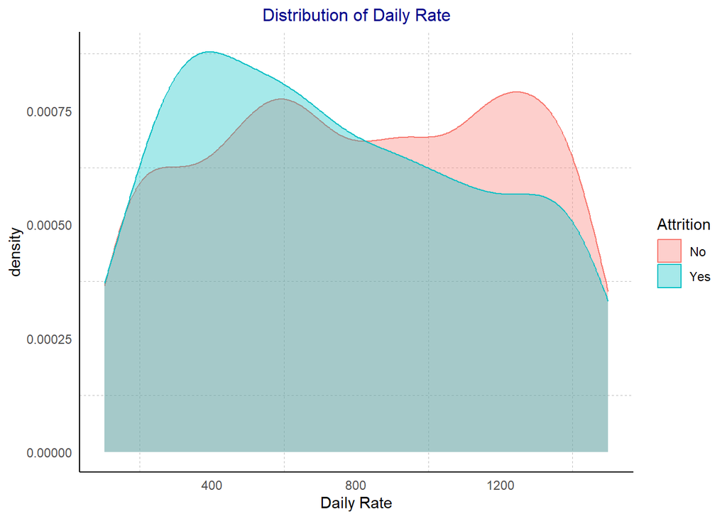

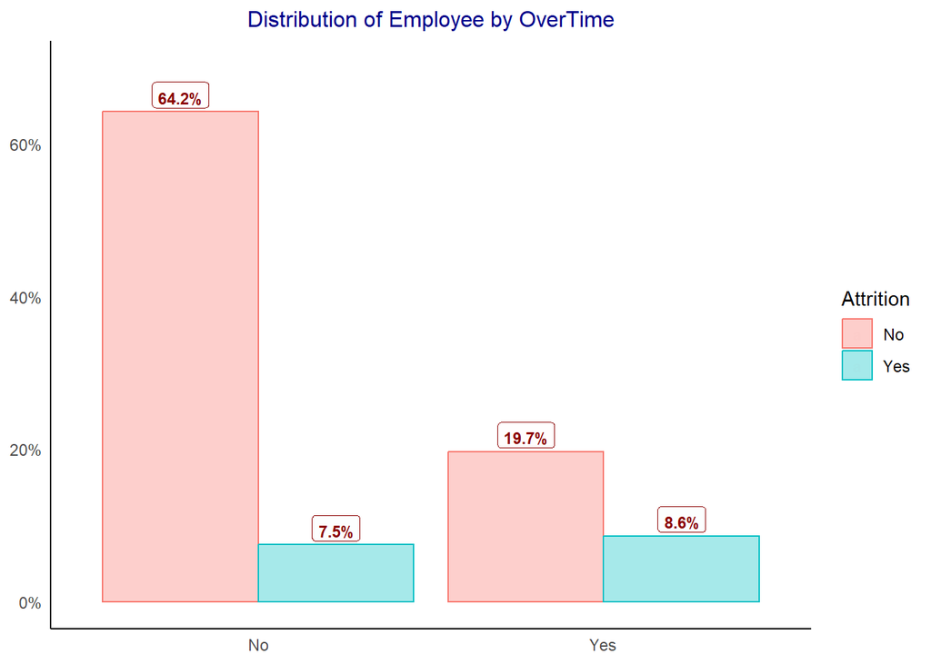

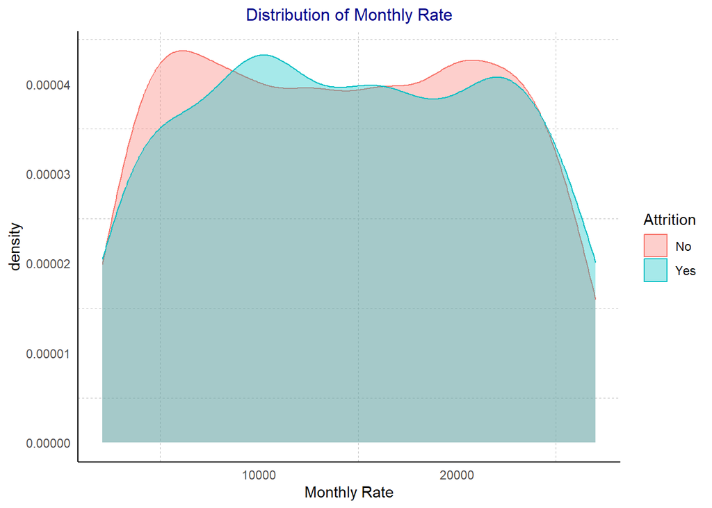

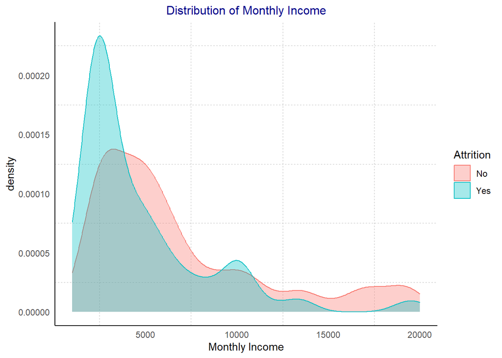

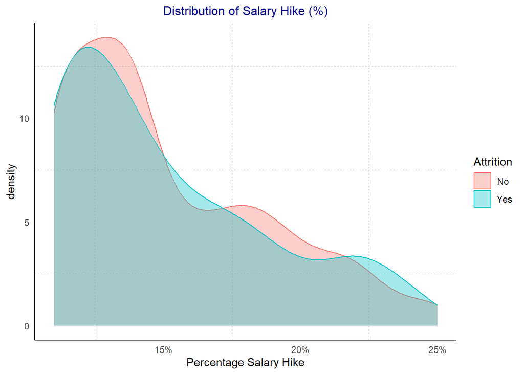

**Job**

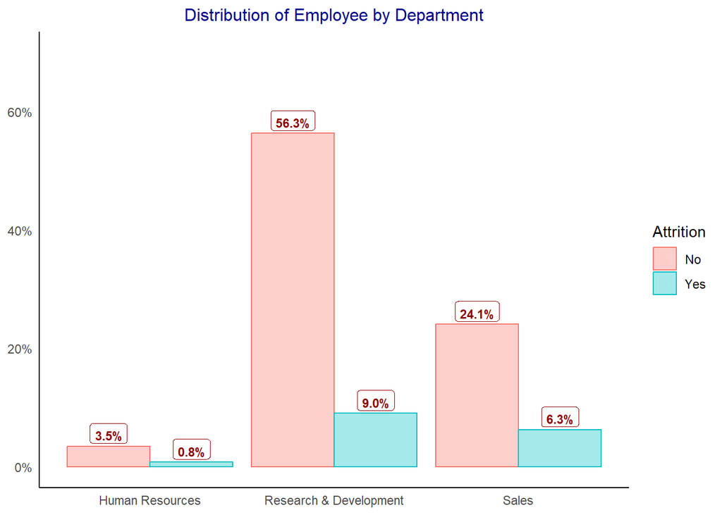

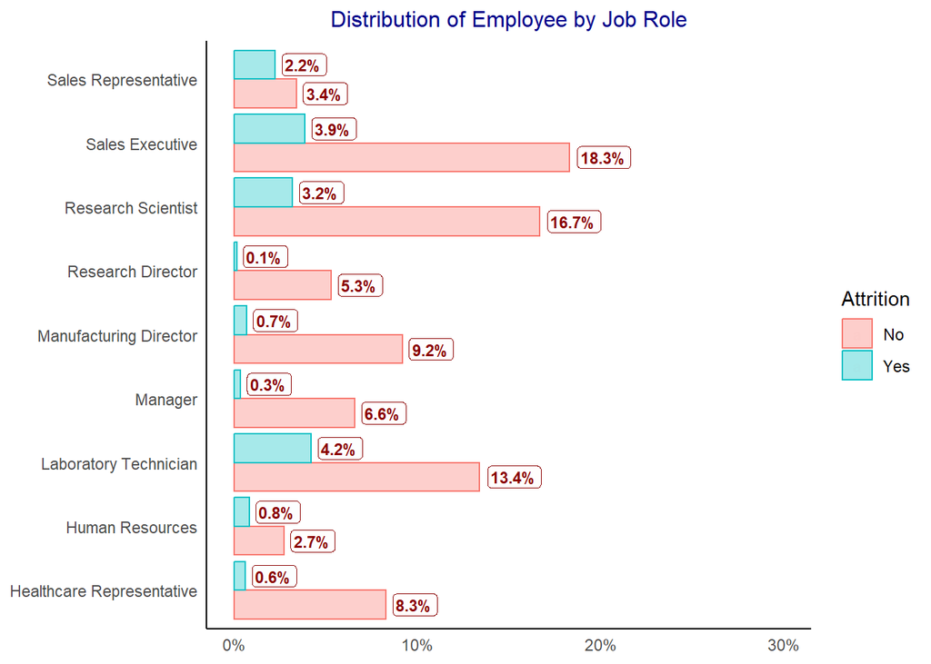

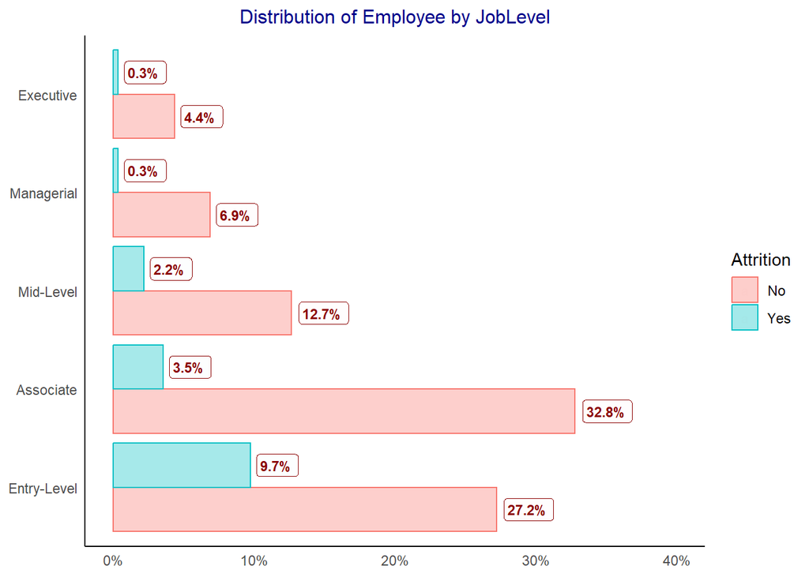

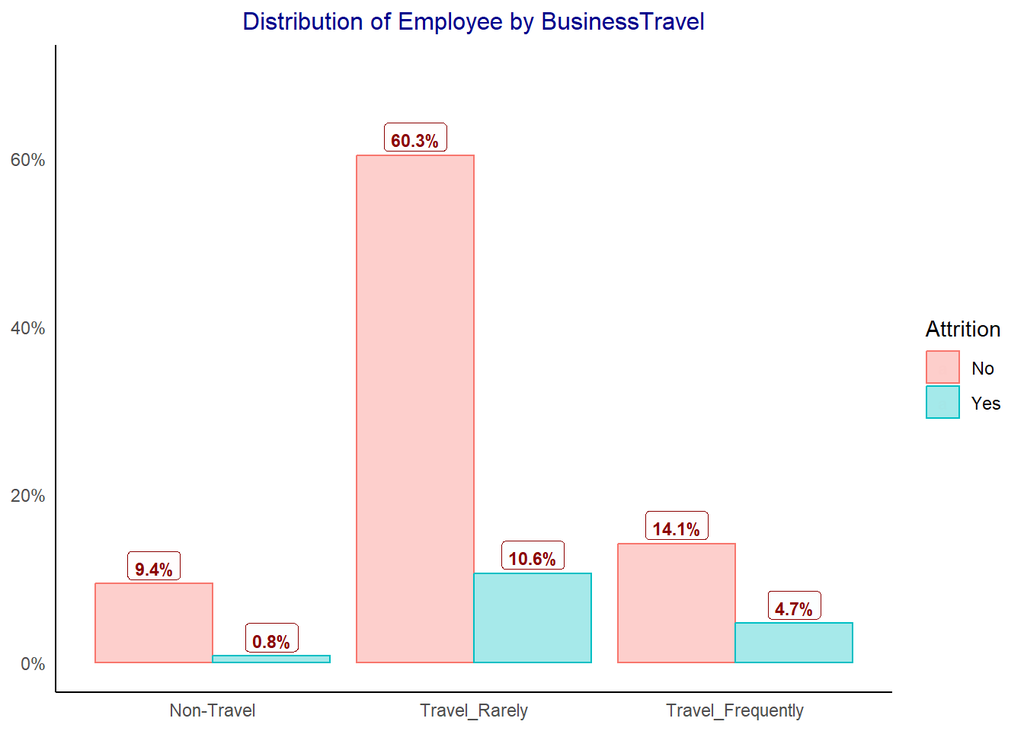

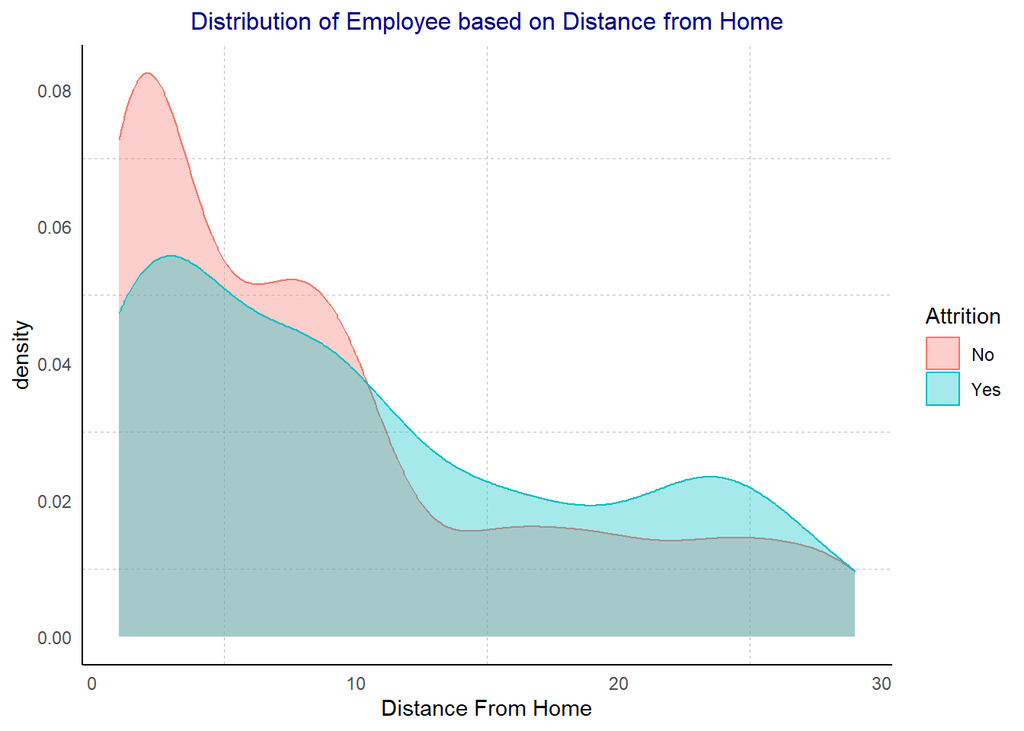

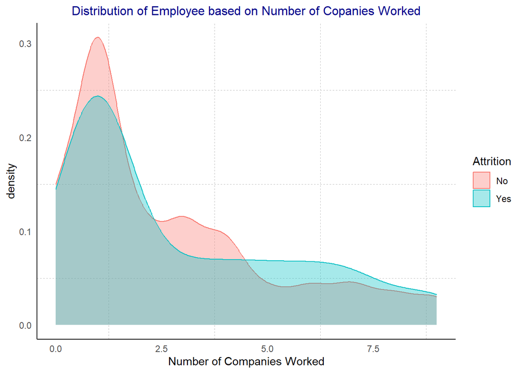

**Ratings**

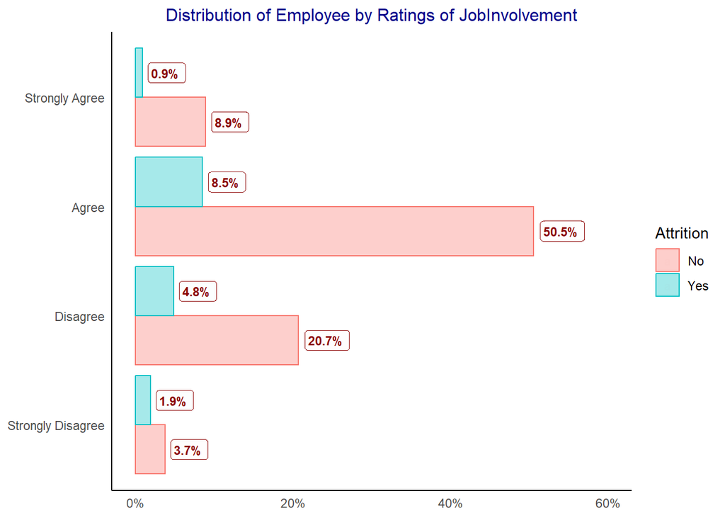

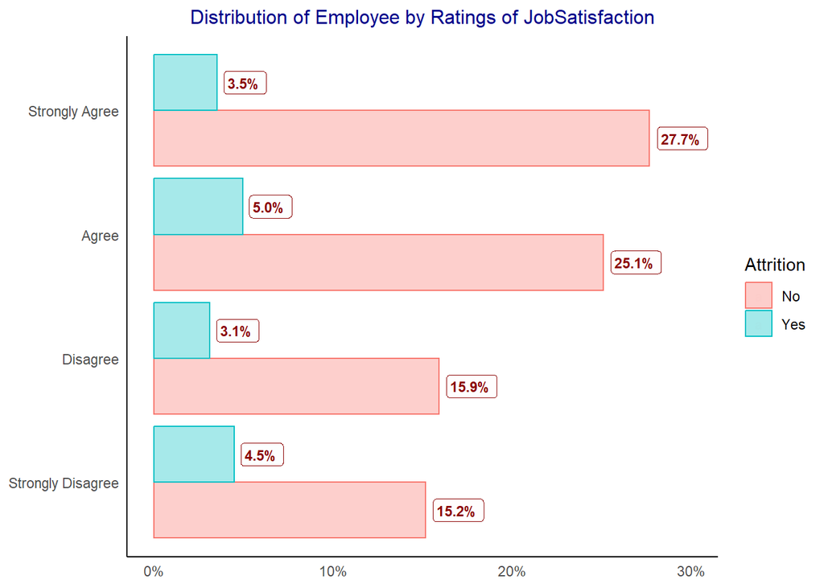

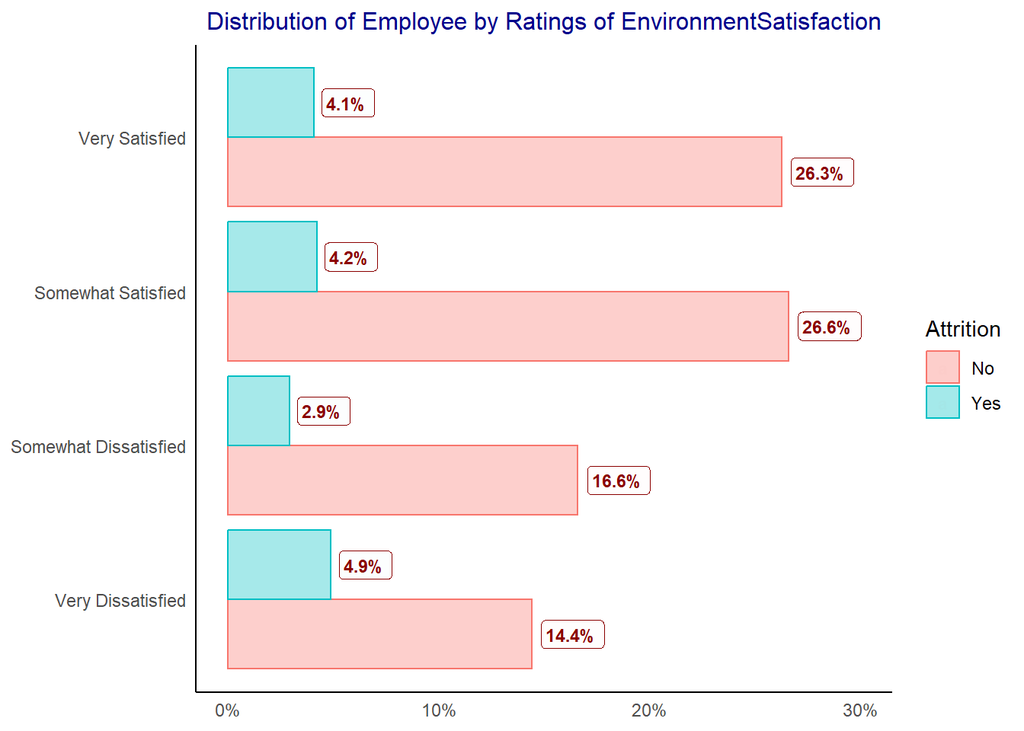

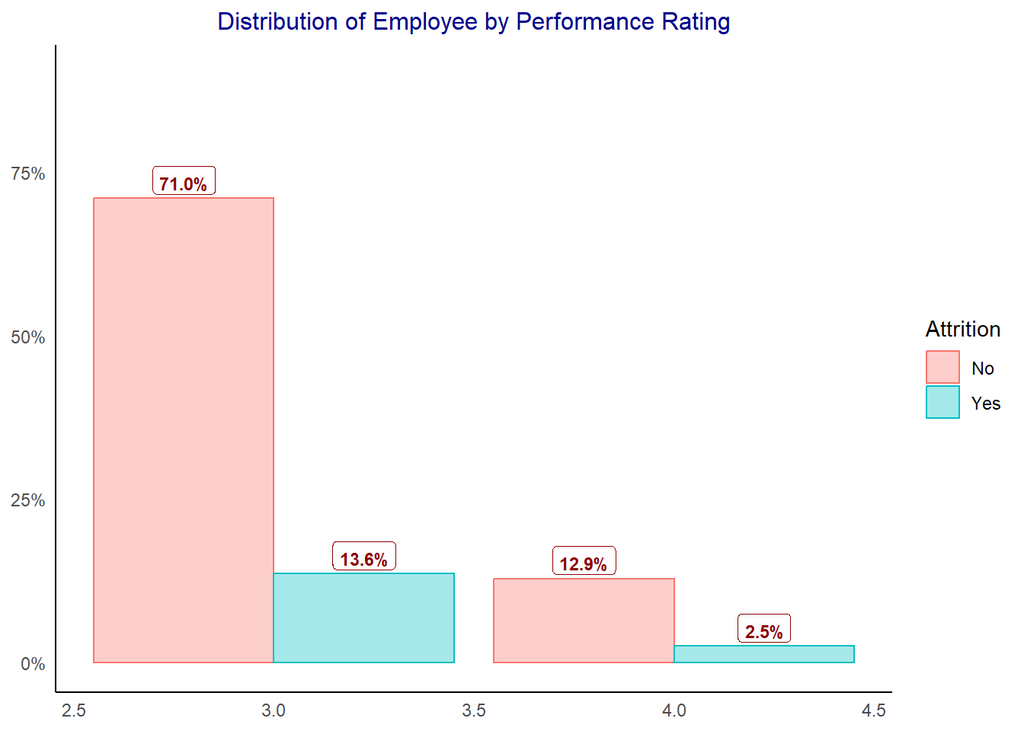

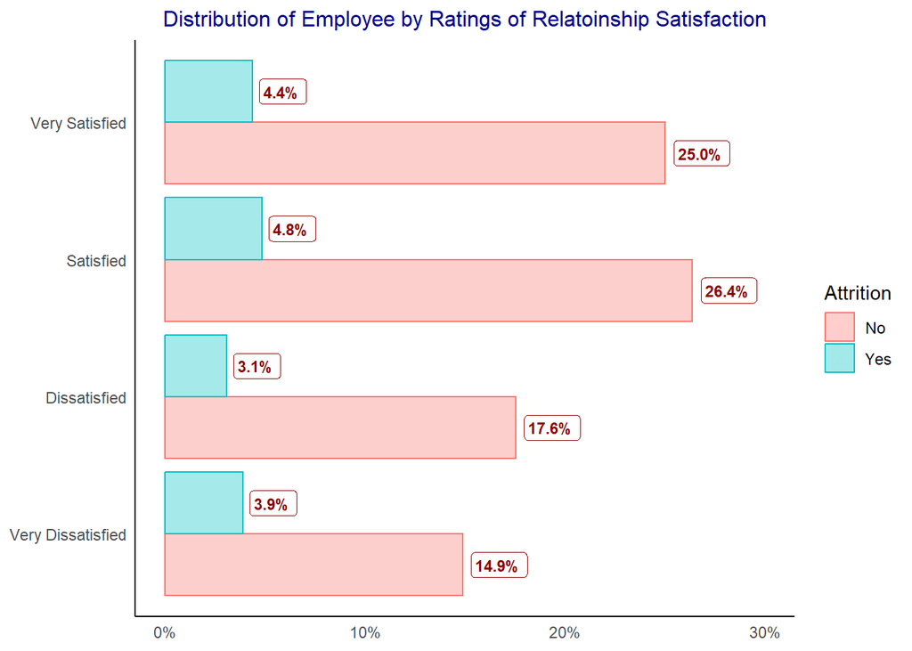

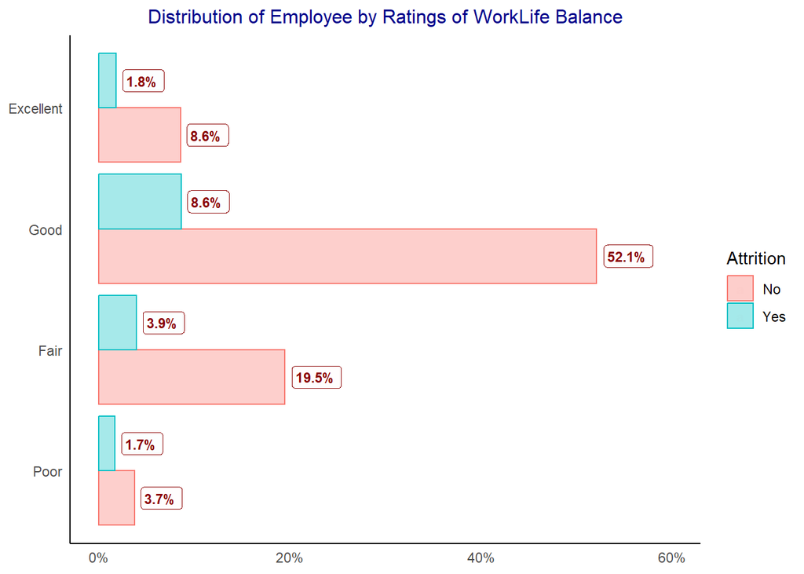

**Tenure**

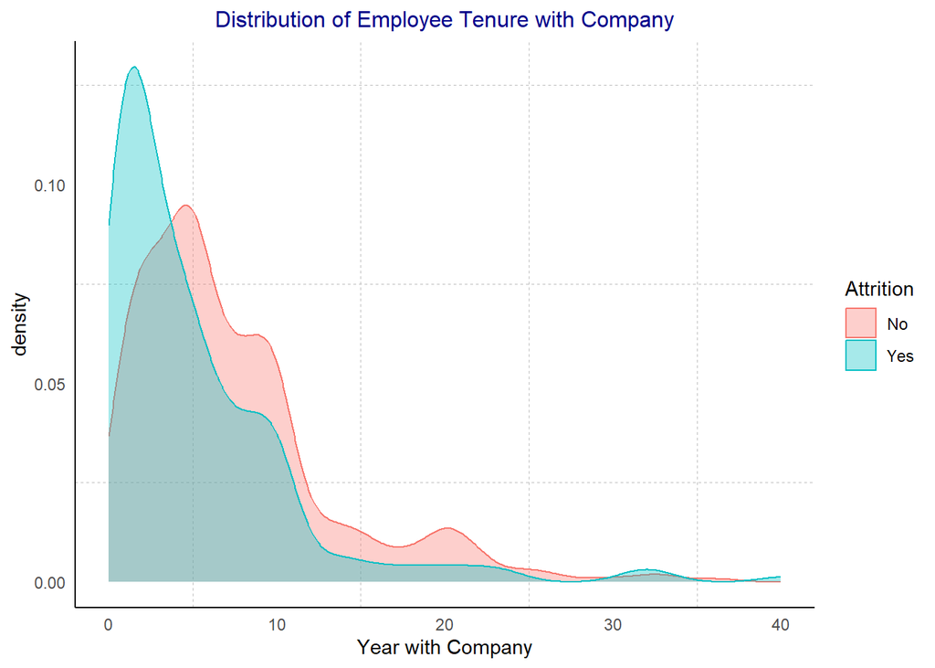

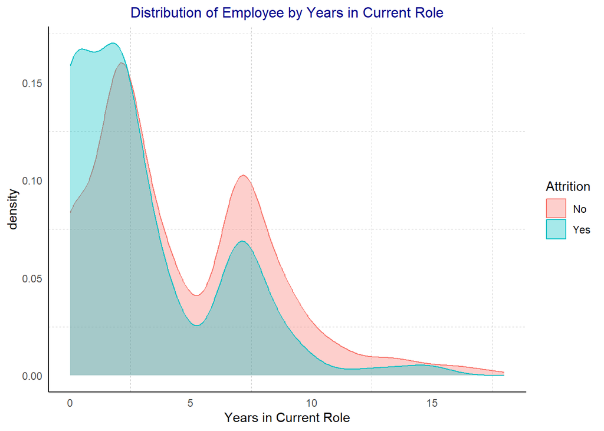

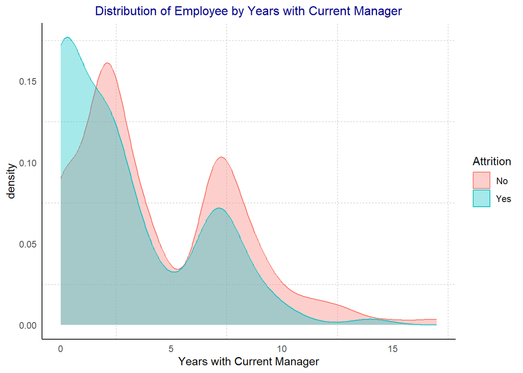

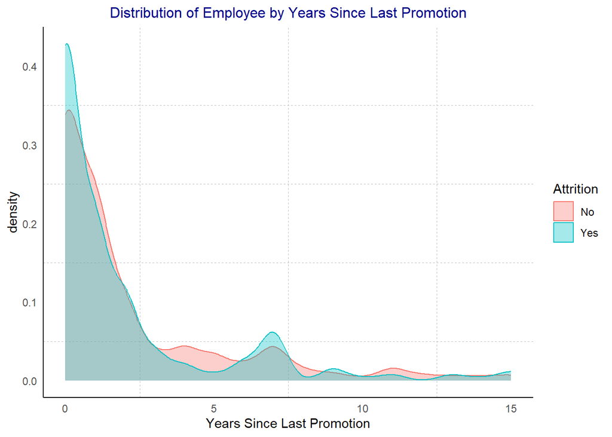

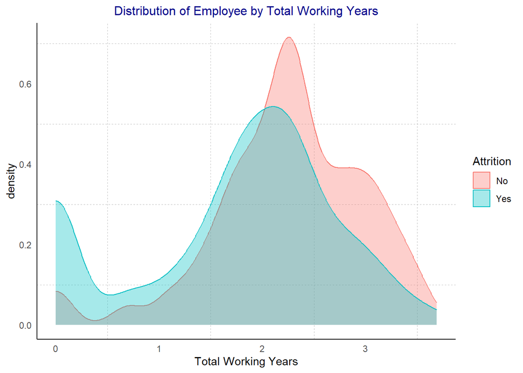

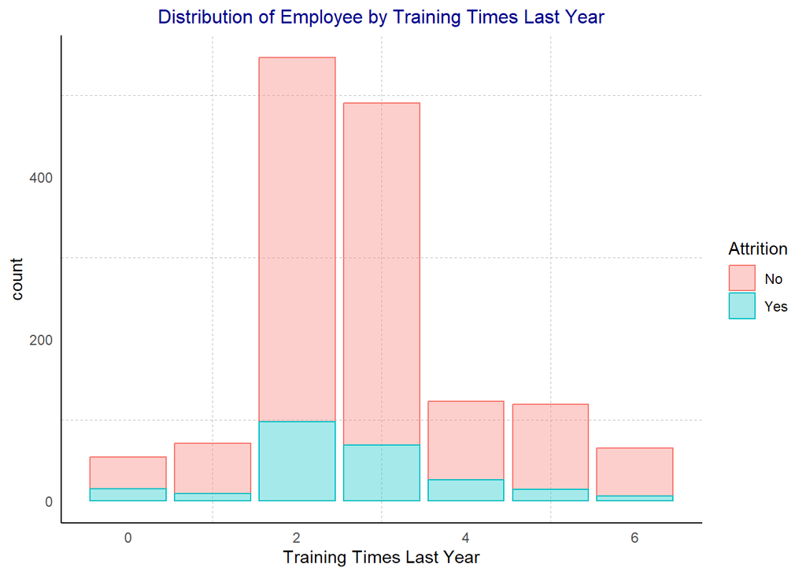

**Others**

[figure not shown]

## Correlation Analysis

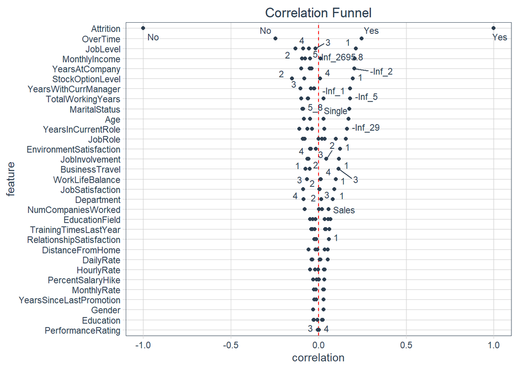

## Model Building

In response to the imbalanced nature of our dataset, I employed three balancing strategies: Adaptive Synthetic Sampling Technique (ADASYN), Synthetic Minority Over-sampling Technique (SMOTE), and Randomly Over Sampling Examples (ROSE). The objective of implementing these techniques is to create a balanced dataset for subsequent modeling stages.

To ensure optimal model performance, we adopted a comprehensive approach that involved utilizing a 10-fold cross-validation dataset derived from our extensive training data. Our modeling efforts were carried out using the robust tidymodel suite of packages, which provided us with a versatile tools to explore and assess various potential models. The range of models considered for evaluation encompassed Logistic Regression, support vector machine, Random Forest, XGBoost, and LightGBM.

To ascertain the most effective model, we employed an efficient grid search approach through racing, coupled with repeated-measure ANOVA, to facilitate the selection process. Each candidate model underwent meticulous tuning to enhance its performance. Below, we present a concise overview of the outcomes derived from our assessment of model performance:

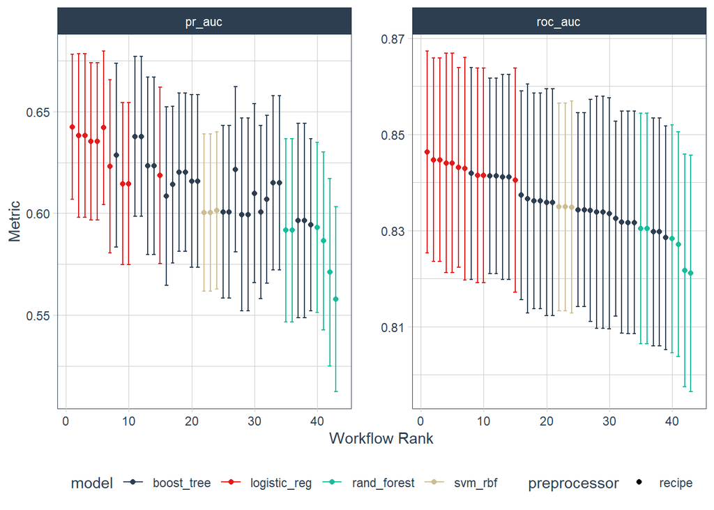

| model | wflow_id | .config | .metric | pr_auc | std_err | rank |
| --- | --- | --- | --- | --- | --- | --- |
| logistic_reg | recip_adasyn_logistic_reg | Preprocessor1_Model13 | pr_auc | 0.642 | 0.022 | 1 |
| logistic_reg | recip_smote_logistic_reg | Preprocessor1_Model03 | pr_auc | 0.638 | 0.024 | 2 |
| logistic_reg | recip_rose_logistic_reg | Preprocessor1_Model03 | pr_auc | 0.638 | 0.024 | 3 |
| logistic_reg | recip_rose_logistic_reg | Preprocessor1_Model13 | pr_auc | 0.635 | 0.023 | 4 |
| logistic_reg | recip_smote_logistic_reg | Preprocessor1_Model13 | pr_auc | 0.635 | 0.023 | 5 |
| logistic_reg | recip_adasyn_logistic_reg | Preprocessor1_Model03 | pr_auc | 0.642 | 0.023 | 6 |
| logistic_reg | recip_adasyn_logistic_reg | Preprocessor1_Model06 | pr_auc | 0.623 | 0.026 | 7 |
| boost_tree | recip_adasyn_lightgbm | Preprocessor1_Model08 | pr_auc | 0.628 | 0.027 | 8 |
| logistic_reg | recip_smote_logistic_reg | Preprocessor1_Model02 | pr_auc | 0.614 | 0.024 | 9 |
| logistic_reg | recip_rose_logistic_reg | Preprocessor1_Model02 | pr_auc | 0.614 | 0.024 | 10 |